# Parameter Estimation of Wild Fish Catch

Catherine Takata

3/2/2021

## Summary

We will identify an equation with parameters estimated by nonlinear least squares for the increase in global wild fish catch from 1950 – 2012.

**Source**: Global wild fish catch and aquaculture production, compiled by Earth Policy Institute with 1950-2010 from U.N. Food and Agriculture Organization (FAO), Global Capture Production and Global Aquaculture Production, electronic databases, at www.fao.org/fishery/topic/16140/en.

```r
# Read in data
fish_catch <- read.csv(here("a4_task2", "data", "fish_catch.csv"), col.names = c("year", "wild_catch", "farmed_fish", "total_fish_production")) %>%
  mutate(time = year)

fish_catch[1:63, 5] = c(0:62)
```

## Exploratory Data Visualization

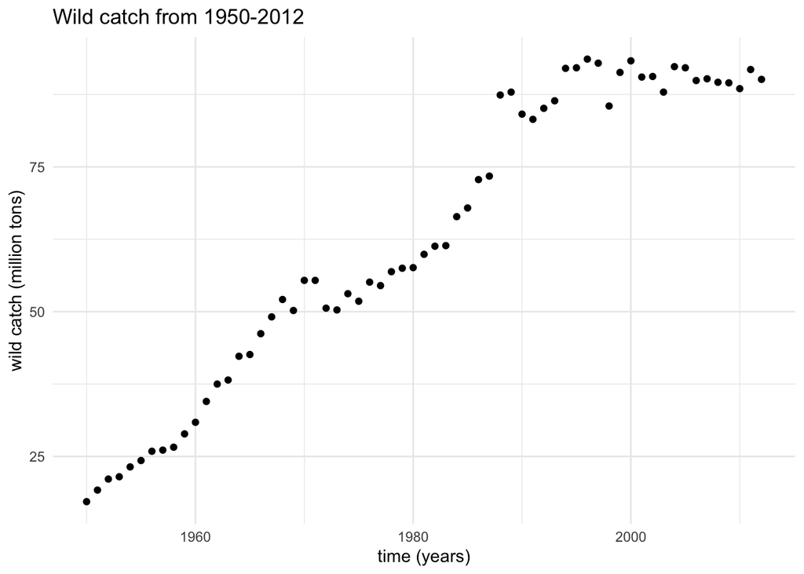

```r
ggplot(data = fish_catch, aes(x = year, y = wild_catch)) +
  geom_point() +
  theme_minimal() +
  labs(title = "Wild catch from 1950-2012",
       x = "time (years)",
       y = "wild catch (million tons)")
```

Our initial exploration reveals a trend simialr to logistic growth of a population over time. As the number of wild catch increase with time, resource limitations halt growth, revealing a carry capacity shown at about 95 million tons of wild catch. Mathematically we can identiify paramters of K and A of the growth equation for the population at time t where:

$$A = \frac{K- P0}{P0}$$
By identifying the relationship between K and A we can further evalute the growth curve for:

$$P(t) = \frac{K}{1+Ae^{-kt}}$$

Our original start estimates of K come from the point at which resrouces stop supporting growth of population at the carring capacity where graph levels out at a constant rate. We can then calculate A as we relate the intial population of ~17 million tons to the carrying capacity. By using non linear least sqaures, we will find parameters to minimize square residuals by using iterative algorithms to converge on parameter estimates (since there is no single equation to calculate exactly what the paramter estimates would be).

## Finalized Parameter Results

**Table 1.** Model parameters (growth rate constant (k), carrying capacity (K), and (A)) for recorded wild fish catch.

```r
model_out %>%
  kbl(col.names = c("Parameter", "Estimate", "Standard Error", "Statistic", "p - value")) %>%
  # kbl/kable() creates a clean data table for the knitted document  with labeled columns
  kable_styling(bootstrap_options = "striped", full_width = FALSE)
```

| Parameter | Estimate | Standard Error | Statistic | p - value |
| --- | --- | --- | --- | --- |
| K | 100.2784366 | 2.7341446 | 36.67635 | <0.0001 |
| A | 4.3163272 | 0.2929403 | 14.73449 | <0.0001 |
| r | 0.0698867 | 0.0046482 | 15.03530 | <0.0001 |

```r
# Make predictions for the population at all of those times (time) in the original df:
p_predict <- predict(fish_nls)

# Bind predictions to original data frame:
fish_complete <- data.frame(fish_catch, p_predict)
```

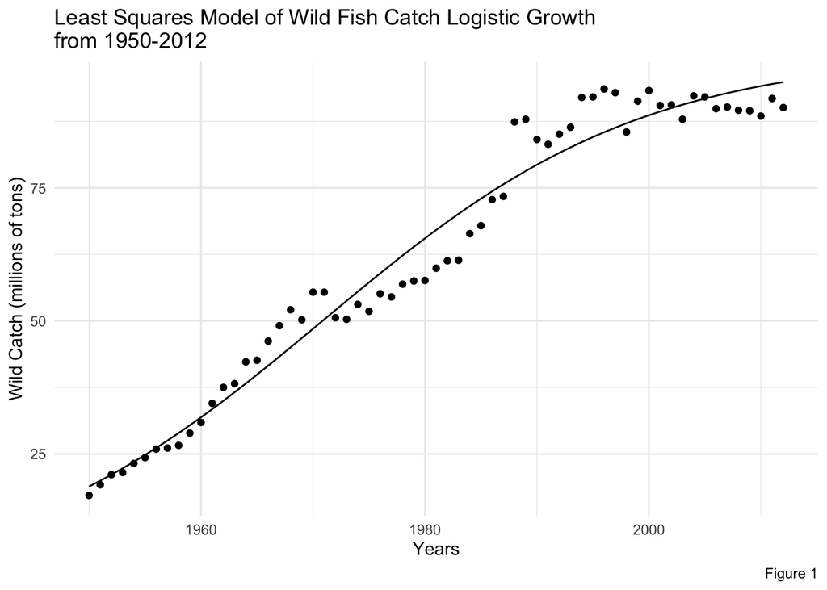

```r
# Plot them all together:
ggplot(data = fish_complete, aes(x = year, y = wild_catch)) +
  geom_point() +
  geom_line(aes(x = year, y = p_predict)) +
  theme_minimal() +
  labs(title = "Least Squares Model of Wild Fish Catch Logistic Growth \nfrom 1950-2012",
       x = "Years",
       y = "Wild Catch (millions of tons)",
       caption = "Figure 1")
```